# Reproducible Research: Peer Assessment 1

### Introduction

It is now possible to collect a large amount of data about personal movement using activity monitoring devices such as a [Fitbit](http://www.fitbit.com), [Nike Fuelband](http://www.nike.com/us/en_us/c/nikeplus-fuelband), or [Jawbone Up](https://jawbone.com/up). These type of devices are part of the “quantified self” movement – a group of enthusiasts who take measurements about themselves regularly to improve their health, to find patterns in their behavior, or because they are tech geeks. But these data remain under-utilized both because the raw data are hard to obtain and there is a lack of statistical methods and software for processing and interpreting the data.

This assignment makes use of data from a personal activity monitoring device. This device collects data at 5 minute intervals through out the day. The data consists of two months of data from an anonymous individual collected during the months of October and November, 2012 and include the number of steps taken in 5 minute intervals each day.

For data source and structure, please read the readme.md file.

### Loading and preprocessing the data

The downloaded zip file has been unzipped and saved to the same directory as the R markdown document, with a name “activity.csv”.  
Data content of the file is read into a data frame called “rawdata”. The dataframe “completedata” is derived from rawdata after removing rows with NA or NaN values.

```r
rawdata <- read.csv('~/Coursera R/Reproducible research/Project 1/repdata-data-activity/activity.csv')
completedata <- rawdata[complete.cases(rawdata),]
```

Any further necessary data processing or transformation steps are shown at the particular analyses below.

### What is mean total number of steps taken per day?

For this part of the assignment, missing values in the dataset are ignored (the “completedata” dataframe is used). The number of steps by days is calculated by the following R script:

```r
stepsbyday <- aggregate(completedata$steps, list(completedata$date), sum)
colnames(stepsbyday) <- c('date', 'daily.steps')
```

The resulting “stepsbyday” object is a data frame with the following structure and summary:

```r
str(stepsbyday)
```

```
## 'data.frame':    53 obs. of  2 variables:
##  $ date       : Factor w/ 61 levels "2012-10-01","2012-10-02",..: 2 3 4 5 6 7 9 10 11 12 ...
##  $ daily.steps: int  126 11352 12116 13294 15420 11015 12811 9900 10304 17382 ...
```

```r
summary(stepsbyday)
```

```
##          date     daily.steps
##  2012-10-02: 1   Min.   :   41
##  2012-10-03: 1   1st Qu.: 8841
##  2012-10-04: 1   Median :10765
##  2012-10-05: 1   Mean   :10766
##  2012-10-06: 1   3rd Qu.:13294
##  2012-10-07: 1   Max.   :21194
##  (Other)   :47
```

**Mean** and **median** numbers of daily steps can be read from the above summary.  
A histogram of daily steps is provided below:

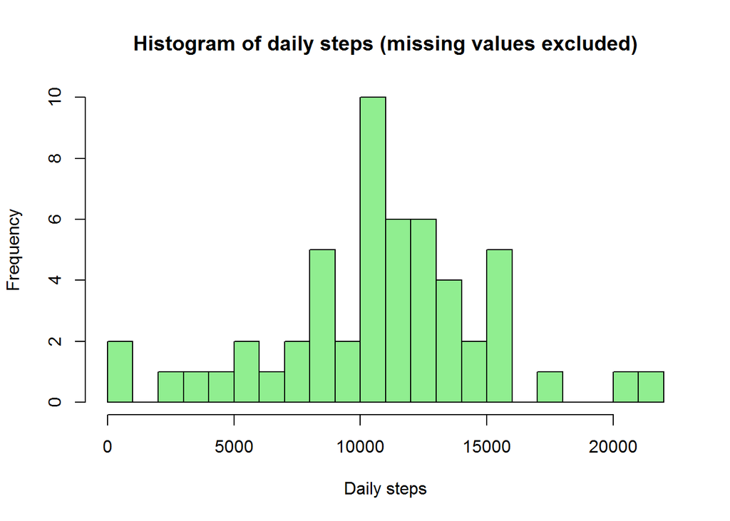

```r
hist(stepsbyday$daily.steps, breaks = 20, main = 'Histogram of daily steps (missing values excluded)', xlab = 'Daily steps', col='lightgreen')
```

### What is the average daily activity pattern?

The number of steps by the 5-minute measurement intervals is averaged across days, skipping the missing values, by the following R script:

```r
stepsbyintervals <- aggregate(completedata$steps, list(completedata$interval), mean)
colnames(stepsbyintervals) <- c('interval', 'steps.in.interval')
```

The resulting “stepsbyintervals” object is a data frame with the following structure:

```r
str(stepsbyintervals)
```

```
## 'data.frame':    288 obs. of  2 variables:
##  $ interval         : int  0 5 10 15 20 25 30 35 40 45 ...
##  $ steps.in.interval: num  1.717 0.3396 0.1321 0.1509 0.0755 ...
```

Average daily activity pattern is shown by the following time series plot:

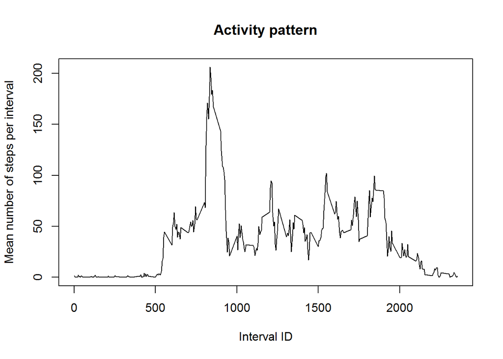

```r
plot(stepsbyintervals$interval, stepsbyintervals$steps.in.interval, type = 'l', main = 'Activity pattern', xlab = 'Interval ID', ylab = 'Mean number of steps per interval')
```

The maximum number of steps was asociated with the following interval ID:

```r
stepsbyintervals[order(stepsbyintervals$steps.in.interval, decreasing='TRUE'), ][1,1]
```

```
## [1] 835
```

Note that interval IDs have 3 or 4 digits, with the last two digits representing minutes, and the preceding 1 or 2 digits representing hours. Interval IDs refer to the beginning of the 5-minute intervals. As illustrations, see the following examples:  
- interval ID ‘835’ represents the interval 08:35:00 - 08:39:59 in the morning;  
- interval ID ‘2255’ represents the interval 22:55:00 - 22:59:59 in the evening.

### Imputing missing values

The total number of missing values in the dataset (i.e. the total number of rows with NAs) is calculated by the following script:

```r
length(rawdata[,1])-length(completedata[,1])
```

```
## [1] 2304
```

For filling in the missing values in the raw dataset, all NA values are replaced by mean number of steps in the corresponding 5-minute intervals. A new dataset with filled missing data (called “filled”) is created by the following R script:

```r
filled <- rawdata
missing <- is.na(rawdata[,1])
for(i in 1:17568){
     if (missing[i] == "TRUE"){filled[i,1] <- stepsbyintervals[((i-1)%%288)+1,2]}
}
```

The number of steps by days (based on the filled data) is calculated by the following R script:

```r
stepsbyday.filled <- aggregate(filled$steps, list(filled$date), sum)
colnames(stepsbyday.filled) <- c('date', 'daily.steps')
```

The resulting “stepsbyday.filled” object is a data frame with the following structure and summary:

```r
str(stepsbyday.filled)
```

```
## 'data.frame':    61 obs. of  2 variables:
##  $ date       : Factor w/ 61 levels "2012-10-01","2012-10-02",..: 1 2 3 4 5 6 7 8 9 10 ...
##  $ daily.steps: num  10766 126 11352 12116 13294 ...
```

```r
summary(stepsbyday.filled)
```

```
##          date     daily.steps
##  2012-10-01: 1   Min.   :   41
##  2012-10-02: 1   1st Qu.: 9819
##  2012-10-03: 1   Median :10766
##  2012-10-04: 1   Mean   :10766
##  2012-10-05: 1   3rd Qu.:12811
##  2012-10-06: 1   Max.   :21194
##  (Other)   :55
```

**Mean** and **median** numbers of daily steps with filled data can be read from the above summary. A histogram of daily steps with filled data is provided below:

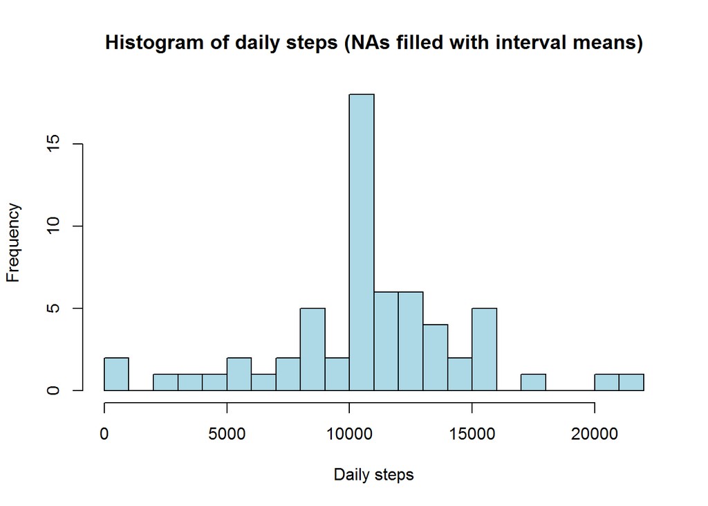

```r
hist(stepsbyday.filled$daily.steps, breaks = 20, main = 'Histogram of daily steps (NAs filled with interval means)', xlab = 'Daily steps', col='lightblue')
```

It is concluded that missing data filling with interval means did not have noticeable effect on mean and median values, although the distribution of daily activity became slightly more homogenous or narrow.

### Are there differences in activity patterns between weekdays and weekends?

Weekdays of calendar days are classified as “weekend” or “weekday” by the following script, adding a new factor column called “wd” to the NA inputed (“filled”) dataset:

```r
Sys.setlocale(category = "LC_TIME", locale = "C") # set locale to "C" for English weekday labels
```

```
## [1] "C"
```

```r
wd <- as.character(weekdays(as.Date(filled[,2])))
for (j in 1:17568){
     if (wd[j] %in% c('Saturday', 'Sunday')){wd[j] <- c('weekend')}
     else {wd[j] <- c('weekday')}
     }
filledwd <- cbind(filled, as.factor(wd))
colnames (filledwd) <- c(colnames(filled), c('wd'))
Sys.setlocale(category = "LC_TIME", locale = "") # restore local time settings
```

```
## [1] "English_United Kingdom.1252"
```

```r
summary(filledwd)
```

```
##      steps               date          interval          wd
##  Min.   :  0.0   2012-10-01:  288   Min.   :   0   weekday:12960
##  1st Qu.:  0.0   2012-10-02:  288   1st Qu.: 589   weekend: 4608
##  Median :  0.0   2012-10-03:  288   Median :1178
##  Mean   : 37.4   2012-10-04:  288   Mean   :1178
##  3rd Qu.: 27.0   2012-10-05:  288   3rd Qu.:1766
##  Max.   :806.0   2012-10-06:  288   Max.   :2355
##                  (Other)   :15840
```

Activity patterns on weekdays and on weekends are calculated and saved to the “profiles” dataframe as shown below:

```r
SaSu <- filledwd[filledwd$wd == 'weekend',]
MTWTF <- filledwd[filledwd$wd == 'weekday',]
SaSuprofile <- data.frame(interval = SaSu$interval, meansteps = aggregate(SaSu$steps, list(SaSu$interval), mean)[,2], wd = 'weekend')
MTWTFprofile <- data.frame(interval = MTWTF$interval, meansteps = aggregate(MTWTF$steps, list(MTWTF$interval), mean)[,2], wd = 'weekday')
profiles <- rbind(SaSuprofile, MTWTFprofile)
profiles$wd <- as.factor(profiles$wd)
```

A 2-panel plot is presented below on the activity patterns on weekdays and weekends:

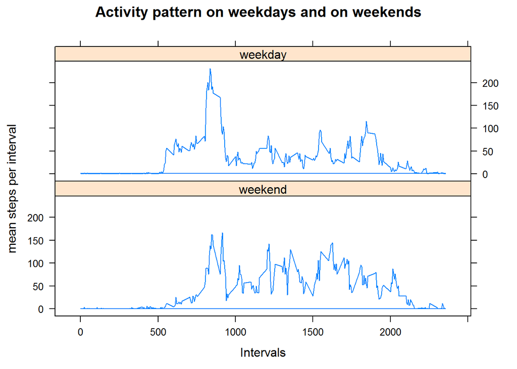

```r
library(lattice)
plot <- xyplot(meansteps ~ interval | wd, data = profiles, type = 'l', layout = c(1,2), xlab = 'Intervals', ylab='mean steps per interval', main = 'Activity pattern on weekdays and on weekends')
print(plot)
```

It seems that the investigated subjects tended to get up later on weekends.

This is the end of the report.